# Interpolación entre imágenes vía transporte óptimo dinámico

### §3.6 — Aceleración: `interp_proj` vectorizado

Mismo cálculo que `interp_proj` (misma `proj_ops`, misma proyección afín por línea), pero apilando las líneas de cada eje como columnas y aplicando $B$, $p_A$ en un producto matricial por eje (BLAS). No cambia los números, solo el costo. **Se activa aquí, antes de toda la validación, para que §4, §5 y §6 corran rápido.** Se prueba contra la versión original antes de activarla.

**Código**

```julia
# interp_proj vectorizado (batch por eje). Reemplazo directo de interp_proj.
function interp_proj_vec(U, V, f0, f1)
    N, P, Q = U.dim
    U = copia(U); V = copy(V)

    # --- eje temporal (k=3): datos a=f0 (t=0), b=f1 (t=1) ---
    pA, B = proj_ops(Q)
    Um = reshape(permutedims(U.M[3], (3,1,2)), Q+1, N*P)
    Vm = reshape(permutedims(V[:,:,:,3], (3,1,2)), Q,   N*P)
    G  = zeros(Q+2, N*P)
    G[Q+1, :] .= vec(f0); G[Q+2, :] .= vec(f1)
    UV = B * vcat(Um, Vm) .+ pA * G
    U.M[3]     = permutedims(reshape(UV[1:Q+1, :],   Q+1, N, P), (2,3,1))
    V[:,:,:,3] = permutedims(reshape(UV[Q+2:end, :], Q,   N, P), (2,3,1))

    # --- eje x (k=1): no-flujo (a=b=0); el eje 1 ya está al frente ---
    pA, B = proj_ops(N)
    Um = reshape(U.M[1],     N+1, P*Q)
    Vm = reshape(V[:,:,:,1], N,   P*Q)
    UV = B * vcat(Um, Vm)
    U.M[1]     = reshape(UV[1:N+1, :],   N+1, P, Q)
    V[:,:,:,1] = reshape(UV[N+2:end, :], N,   P, Q)

    # --- eje y (k=2): no-flujo (a=b=0) ---
    pA, B = proj_ops(P)
    Um = reshape(permutedims(U.M[2], (2,1,3)), P+1, N*Q)
    Vm = reshape(permutedims(V[:,:,:,2], (2,1,3)), P,   N*Q)
    UV = B * vcat(Um, Vm)
    U.M[2]     = permutedims(reshape(UV[1:P+1, :],   P+1, N, Q), (2,1,3))
    V[:,:,:,2] = permutedims(reshape(UV[P+2:end, :], P,   N, Q), (2,1,3))

    return U, V
end
println("interp_proj_vec lista.")
```

```
interp_proj_vec lista.
```

**Código**

```julia
# TEST §6.2: interp_proj_vec debe coincidir con interp_proj (≈1e-12) sobre un campo aleatorio.
let
    N, P, Q = 12, 10, 8
    U  = random_staggered((N,P,Q)); V = randn(N,P,Q,3)
    f0 = rand(N,P); f1 = rand(N,P)
    U1, V1 = interp_proj(copia(U), copy(V), f0, f1)
    U2, V2 = interp_proj_vec(copia(U), copy(V), f0, f1)
    eU = maximum(maximum(abs.(U1.M[k] .- U2.M[k])) for k in 1:3)
    eV = maximum(abs.(V1 .- V2))
    @printf("dif U = %.2e   dif V = %.2e   (debe ser ≈1e-12)\n", eU, eV)
    @assert eU < 1e-10 && eV < 1e-10
    println("OK: versión vectorizada equivalente.")
end
```

```
dif U = 8.88e-16   dif V = 6.66e-16   (debe ser ≈1e-12)
OK: versión vectorizada equivalente.
```

**Código**

```julia
# Activa la versión rápida: a partir de aquí solve_bb usa interp_proj_vec. Ejecutar solo si el TEST pasó.
interp_proj(U, V, f0, f1) = interp_proj_vec(U, V, f0, f1)
println("interp_proj ahora usa la ruta vectorizada.")
```

```
interp_proj ahora usa la ruta vectorizada.
```

## §4 — Validación numérica

**Código**

```julia
# gaussiana normalizada a masa 1.
function gaussiana(dim2d, centro, σ)
    N, P = dim2d
    cx, cy = centro
    x = range(0, 1; length=N)
    y = range(0, 1; length=P)
    G = [exp(-((xi-cx)^2 + (yj-cy)^2)/(2σ^2)) for xi in x, yj in y]
    return G ./ sum(G)
end

# blending lineal rho_t=(1-t)f0+t f1.
function blending(f0, f1, Q)
    N, P = size(f0)
    out = zeros(N, P, Q+1)
    ts = range(0, 1; length=Q+1)
    for i in 1:(Q+1)
        out[:,:,i] = (1-ts[i]) .* f0 .+ ts[i] .* f1
    end
    return out
end

# dispersion espacial de una densidad 2D (varianza respecto al centro de masa).
function dispersion(ρ2d)
    N, P = size(ρ2d)
    x = range(0,1;length=N); y = range(0,1;length=P)
    m = sum(ρ2d)
    cx = sum([x[i]*ρ2d[i,j] for i in 1:N, j in 1:P]) / m
    cy = sum([y[j]*ρ2d[i,j] for i in 1:N, j in 1:P]) / m
    v  = sum([((x[i]-cx)^2+(y[j]-cy)^2)*ρ2d[i,j] for i in 1:N, j in 1:P]) / m
    return v, (cx, cy)
end
println("Utilidades de validacion listas.")
```

```
Utilidades de validacion listas.
```

### §4.1 — Benchmark gaussiano (Teorema 4.1)

Dos gaussianas trasladadas: la solución es la gaussiana que se mueve a velocidad constante. Validamos contra esa referencia exacta, y comparamos con el blending (que desvanece/aparece).

**Código**

```julia
# EXPERIMENTO: benchmark gaussiano.
d = (32, 32, 32); σ = 0.15; piso = 1e-4          # <- 16→32 aquí
f0 = gaussiana((d[1],d[2]), (0.3,0.3), σ); f0 .+= piso; f0 ./= sum(f0)
f1 = gaussiana((d[1],d[2]), (0.7,0.7), σ); f1 .+= piso; f1 ./= sum(f1)
ε  = minimum(f0)

Xu, V, hist = solve_bb(f0, f1, d; β=1.0, ε=ε, γ=1/230, niter=500)   # <- niter 500→1000

@printf("||div|| :  inicial=%.2e  final=%.2e\n", hist.div[1], hist.div[end])
@printf("min rho :  final=%.2e\n", hist.minρ[end])

mid = d[3] ÷ 2
spTO, cmTO = dispersion(V[:,:,mid,3])
bl = blending(f0, f1, d[3]); spBL, cmBL = dispersion(bl[:,:,mid])
@printf("En t=0.5:  dispersion TO=%.4f  blending=%.4f\n", spTO, spBL)

errs = Float64[]
for j in 1:d[3]
    t = (j-0.5)/d[3]
    c = ((1-t)*0.3+t*0.7, (1-t)*0.3+t*0.7)
    re = gaussiana((d[1],d[2]), c, σ); re .+= piso; re ./= sum(re)    # <- también parametrizado
    push!(errs, norm(V[:,:,j,3] .- re)/norm(re))
end
@printf("Error L2 densidad vs exacta:  max=%.3f  medio=%.3f\n", maximum(errs), sum(errs)/length(errs))
```

```
||div|| :  inicial=2.34e-03  final=1.17e-04
min rho :  final=8.05e-05
En t=0.5:  dispersion TO=0.0580  blending=0.1211
Error L2 densidad vs exacta:  max=0.044  medio=0.035
```

### §4.2 — Verificación de las condiciones de optimalidad

El Teorema 2.7 caracteriza el óptimo por el flujo potencial $v=\nabla\varphi$ y la ecuación de Hamilton–Jacobi $\partial_t\varphi+\tfrac12|\nabla\varphi|^2=0$. Reconstruir $\varphi$ es inestable (en el vacío $v=m/\rho$ no está definido), así que medimos las condiciones en su **forma equivalente** sobre la velocidad $v$:

- Flujo potencial $v=\nabla\varphi$ $\iff$ $v$ irrotacional: $\partial_x v_y-\partial_y v_x=0$.
- Hamilton–Jacobi $\iff$ $\partial_t v+\tfrac12\nabla|v|^2=0$ (gradiente espacial de la HJ).

Residuos ponderados por la masa:
$$R_v=\Big(\tfrac{1}{\|\rho\|_1}\textstyle\sum\rho\,(\partial_x v_y-\partial_y v_x)^2\Big)^{1/2},\quad
R_{HJ}=\Big(\tfrac{1}{\|\rho\|_1}\textstyle\sum\rho\,\big|\partial_t v+\tfrac12\nabla|v|^2\big|^2\Big)^{1/2}.$$
Deben decrecer con las iteraciones hasta el nivel de la solución exacta discreta.

**Código**

```julia
# derivada centrada a lo largo de un eje (interior centrado, bordes unilateral).
function deriv(f, h, dim)
    g = zeros(size(f))
    if dim == 1
        g[2:end-1,:,:] = (f[3:end,:,:] .- f[1:end-2,:,:]) ./ (2h)
        g[1,:,:]       = (f[2,:,:]   .- f[1,:,:])     ./ h
        g[end,:,:]     = (f[end,:,:] .- f[end-1,:,:]) ./ h
    elseif dim == 2
        g[:,2:end-1,:] = (f[:,3:end,:] .- f[:,1:end-2,:]) ./ (2h)
        g[:,1,:]       = (f[:,2,:]   .- f[:,1,:])     ./ h
        g[:,end,:]     = (f[:,end,:] .- f[:,end-1,:]) ./ h
    else
        g[:,:,2:end-1] = (f[:,:,3:end] .- f[:,:,1:end-2]) ./ (2h)
        g[:,:,1]       = (f[:,:,2]   .- f[:,:,1])     ./ h
        g[:,:,end]     = (f[:,:,end] .- f[:,:,end-1]) ./ h
    end
    return g
end

# residuos de optimalidad, medidos sobre la velocidad v = m/rho.
function residuos_optimalidad(V)
    N, P, Q = size(V,1), size(V,2), size(V,3)
    mx = V[:,:,:,1]; my = V[:,:,:,2]; ρ = V[:,:,:,3]
    εv = 1e-2 * maximum(ρ)              # regularizacion moderada: en el vacio v~0
    vx = mx ./ (ρ .+ εv)
    vy = my ./ (ρ .+ εv)
    hx = 1/N; hy = 1/P; ht = 1/Q
    masa = sum(max.(ρ, 0.0))
    # flujo potencial: rot(v) = d vy/dx - d vx/dy debe ser 0
    rot = deriv(vy, hx, 1) .- deriv(vx, hy, 2)
    Rv  = sqrt(sum(max.(ρ,0.0) .* rot.^2) / masa)
    # Hamilton-Jacobi: d_t v + 1/2 grad|v|^2 = 0
    v2  = vx.^2 .+ vy.^2
    hjx = deriv(vx, ht, 3) .+ 0.5 .* deriv(v2, hx, 1)
    hjy = deriv(vy, ht, 3) .+ 0.5 .* deriv(v2, hy, 2)
    RHJ = sqrt(sum(max.(ρ,0.0) .* (hjx.^2 .+ hjy.^2)) / masa)
    return Rv, RHJ
end
println("residuos_optimalidad lista.")
```

```
residuos_optimalidad lista.
```

**Código**

```julia
println("Residuos de optimalidad vs iteraciones:")
nits = [100, 300, 600]
Rv_list = Float64[]; RHJ_list = Float64[]
for nit in nits
    _, Vn, _ = solve_bb(f0, f1, d; β=1.0, ε=ε, niter=nit)
    Rv, RHJ = residuos_optimalidad(Vn)
    push!(Rv_list, Rv); push!(RHJ_list, RHJ)
    @printf("  niter=%4d   R_v=%.3e   R_HJ=%.3e\n", nit, Rv, RHJ)
end
```

```
Residuos de optimalidad vs iteraciones:
  niter= 100   R_v=4.114e-01   R_HJ=3.509e-01
  niter= 300   R_v=2.398e-01   R_HJ=1.233e-01
  niter= 600   R_v=2.342e-01   R_HJ=1.045e-01
```

**Código**

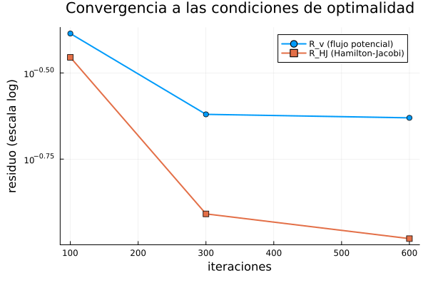

```julia
figr = plot(nits, Rv_list,  label="R_v (flujo potencial)", lw=2, marker=:circle, yscale=:log10)
plot!(nits, RHJ_list, label="R_HJ (Hamilton-Jacobi)", lw=2, marker=:square)
plot!(xlabel="iteraciones", ylabel="residuo (escala log)",
      title="Convergencia a las condiciones de optimalidad")
savefig(figr, "residuos.png")
figr
```

**Código**

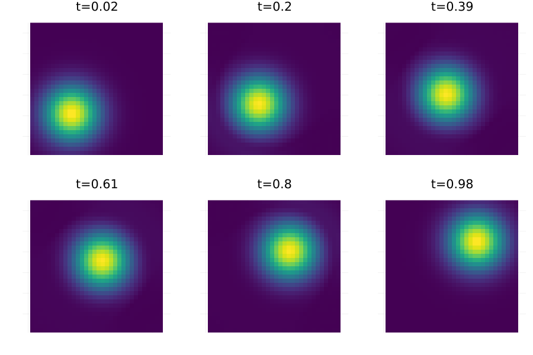

```julia
sel = round.(Int, range(1, d[3]; length=6))
plts = [heatmap(V[:,:,j,3]', c=:viridis, axis=false, legend=false, colorbar=false,
                aspect_ratio=:equal, title="t=$(round((j-0.5)/d[3], digits=2))") for j in sel]
fig = plot(plts..., layout=(2,3), size=(900,600))
savefig(fig, "morphing_gaussianas.png")   # guarda para la PPT
fig                                        # <- ultima linea: la muestra
```

**Código**

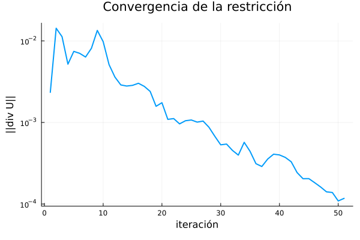

```julia
fig2 = plot(hist.div, yscale=:log10, xlabel="iteración", ylabel="||div U||",
            legend=false, title="Convergencia de la restricción", lw=2)
savefig(fig2, "convergencia.png")
fig2
```

**Código**

```
[ Info: Saved animation to C:\Users\Admin\OneDrive\Desktop\cosas nayin\morphing\morphing\morphing.gif
```

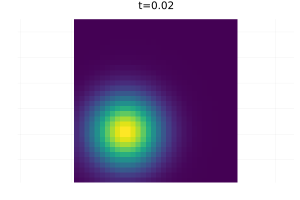

```julia
anim = @animate for j in 1:d[3]
    heatmap(V[:,:,j,3]', c=:viridis, axis=false, legend=false, colorbar=false,
            aspect_ratio=:equal, title="t=$(round((j-0.5)/d[3], digits=2))")
end
gif(anim, "morphing.gif", fps=8)
```

### §4.3 — Comparación con la mezcla lineal

$B(\rho^\*,m^\*)\le B(\rho^{bl},m^{bl})$: el transporte es más barato que la mezcla; y cualitativamente desplaza la masa en vez de desvanecerla (ver la dispersión en §4.1).

**Código**

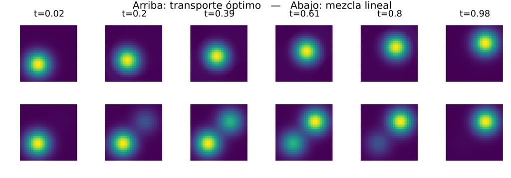

```julia
# densidad del blending en los mismos centros temporales que V (para comparar 1 a 1)
bl_c = zeros(d[1], d[2], d[3])
for j in 1:d[3]
    t = (j-0.5)/d[3]
    bl_c[:,:,j] = (1-t) .* f0 .+ t .* f1
end

selc = round.(Int, range(1, d[3]; length=6))
fila_TO = [heatmap(V[:,:,j,3]', c=:viridis, axis=false, legend=false, colorbar=false,
                   aspect_ratio=:equal, title="t=$(round((j-0.5)/d[3],digits=2))") for j in selc]
fila_BL = [heatmap(bl_c[:,:,j]', c=:viridis, axis=false, legend=false, colorbar=false,
                   aspect_ratio=:equal) for j in selc]
figc = plot(vcat(fila_TO, fila_BL)..., layout=(2,6), size=(1200,420),
            plot_title="Arriba: transporte óptimo   —   Abajo: mezcla lineal")
savefig(figc, "to_vs_blending.png")
figc
```

**Código**

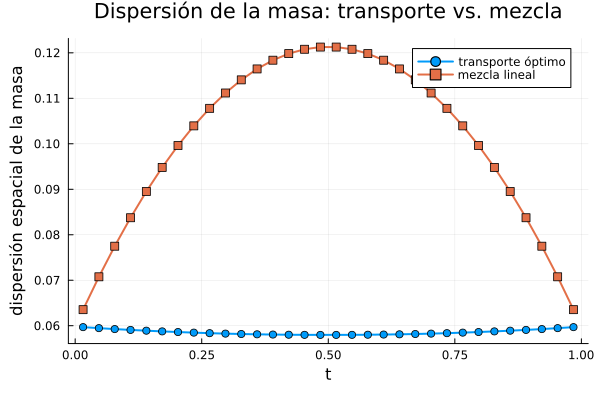

```julia
disp_TO = [dispersion(V[:,:,j,3])[1] for j in 1:d[3]]
disp_BL = [dispersion(bl_c[:,:,j])[1]  for j in 1:d[3]]
tt = [(j-0.5)/d[3] for j in 1:d[3]]
figd = plot(tt, disp_TO, label="transporte óptimo", lw=2, marker=:circle)
plot!(tt, disp_BL, label="mezcla lineal", lw=2, marker=:square)
plot!(xlabel="t", ylabel="dispersión espacial de la masa",
      title="Dispersión de la masa: transporte vs. mezcla")
savefig(figd, "dispersion.png")
figd
```

### §4.4 — Conservación de masa

La ecuación de continuidad conserva la masa: $\int\rho(t,\cdot)=1$ para todo $t$, no solo en los extremos. Verificarlo es un test físico del método (se mide sobre la solución ya calculada, sin costo adicional).

**Código**

```
Masa total:  min=0.999976  max=1.000041  desv.rel.max=6.52e-05
```

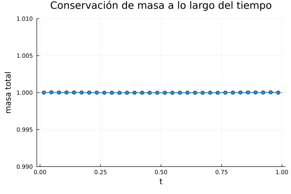

```julia
# Conservacion de masa: la masa total debe ser 1 en TODO instante (no solo en los extremos).
masas = [sum(V[:,:,j,3]) for j in 1:d[3]]
tt    = [(j-0.5)/d[3] for j in 1:d[3]]
@printf("Masa total:  min=%.6f  max=%.6f  desv.rel.max=%.2e\n",
        minimum(masas), maximum(masas),
        (maximum(masas)-minimum(masas))/(sum(masas)/length(masas)))
figm = plot(tt, masas, lw=2, marker=:circle, legend=false,
            xlabel="t", ylabel="masa total",
            title="Conservación de masa a lo largo del tiempo")
hline!([1.0], ls=:dash, color=:gray)
ylims!(0.99, 1.01)
savefig(figm, "conservacion_masa.png")
figm
```

**Código**

```julia
# Densidad gaussiana con piso de fondo de fracción fija (comparable entre resoluciones).
function gauss_densidad(N, centro, σ; frac=0.01)
    g = gaussiana((N,N), centro, σ)          # ya suma 1
    c = frac / ((1-frac)*N^2)                # masa de fondo ≈ frac del total
    g .+= c
    return g ./ sum(g)
end

# Nombres propios (fa, fb, dd, ...) para no sobrescribir f0/f1/d/ε del benchmark.
Ns = (16, 24, 32)                            # ampliar a 40, 48 si el tiempo lo permite
σc = 0.15; c0 = (0.3,0.3); c1 = (0.7,0.7)
errL2 = Float64[]; divf = Float64[]; Rvf = Float64[]; RHJf = Float64[]

for N in Ns
    dd = (N,N,N)
    fa = gauss_densidad(N, c0, σc); fb = gauss_densidad(N, c1, σc)
    epsN = min(minimum(fa), minimum(fb))
    niter = 600 + 30N                       # más resolución -> más iteraciones
    @time _, Vg, hg = solve_bb(fa, fb, dd; β=1.0, ε=epsN, γ=1/230, niter=niter, verbose=200)
    es = Float64[]                           # error L2 vs geodésica gaussiana exacta (mismo piso)
    for j in 1:N
        t  = (j-0.5)/N
        cc = ((1-t)*c0[1]+t*c1[1], (1-t)*c0[2]+t*c1[2])
        re = gauss_densidad(N, cc, σc)
        push!(es, norm(Vg[:,:,j,3] .- re)/norm(re))
    end
    Rv, RHJ = residuos_optimalidad(Vg)
    push!(errL2, sum(es)/length(es)); push!(divf, hg.div[end]); push!(Rvf, Rv); push!(RHJf, RHJ)
    @printf("N=%2d  errL2=%.3f  ||div||=%.2e  R_v=%.2e  R_HJ=%.2e  (niter=%d)\n",
            N, errL2[end], divf[end], Rv, RHJ, niter)
end
```

```
    it=   1/1080  ||div||=1.03e-02  minρ=3.91e-05
    it=  10/1080  ||div||=4.05e-02  minρ=-6.41e-04
    it=  20/1080  ||div||=1.66e-02  minρ=-5.84e-04
    it=  30/1080  ||div||=1.77e-02  minρ=-6.37e-04
    it=  40/1080  ||div||=1.33e-02  minρ=-7.76e-04
    it=  50/1080  ||div||=1.18e-02  minρ=-7.92e-04
    it=  60/1080  ||div||=1.49e-02  minρ=-8.06e-04
    it=  70/1080  ||div||=1.11e-02  minρ=-8.37e-04
    it=  80/1080  ||div||=1.13e-02  minρ=-8.01e-04
    it=  90/1080  ||div||=9.25e-03  minρ=-8.68e-04
    it= 100/1080  ||div||=8.44e-03  minρ=-7.73e-04
    it= 110/1080  ||div||=7.48e-03  minρ=-6.83e-04
    it= 120/1080  ||div||=6.90e-03  minρ=-6.13e-04
    it= 130/1080  ||div||=5.20e-03  minρ=-5.72e-04
    it= 140/1080  ||div||=5.34e-03  minρ=-4.35e-04
    it= 150/1080  ||div||=5.80e-03  minρ=-3.34e-04
    it= 160/1080  ||div||=5.26e-03  minρ=-2.12e-04
    it= 170/1080  ||div||=4.55e-03  minρ=-2.00e-04
    it= 180/1080  ||div||=5.18e-03  minρ=-2.08e-04
    it= 190/1080  ||div||=4.58e-03  minρ=-1.76e-04
    it= 200/1080  ||div||=4.42e-03  minρ=-1.88e-04
    it= 210/1080  ||div||=3.92e-03  minρ=-1.79e-04
    it= 220/1080  ||div||=3.63e-03  minρ=-2.12e-04
    it= 230/1080  ||div||=3.33e-03  minρ=-1.96e-04
    it= 240/1080  ||div||=3.07e-03  minρ=-1.86e-04
    it= 250/1080  ||div||=2.71e-03  minρ=-1.82e-04
    it= 260/1080  ||div||=2.58e-03  minρ=-1.70e-04
    it= 270/1080  ||div||=2.05e-03  minρ=-1.49e-04
    it= 280/1080  ||div||=2.30e-03  minρ=-1.49e-04
    it= 290/1080  ||div||=2.19e-03  minρ=-1.53e-04
    it= 300/1080  ||div||=1.99e-03  minρ=-1.44e-04
    it= 310/1080  ||div||=1.74e-03  minρ=-1.30e-04
    it= 320/1080  ||div||=1.67e-03  minρ=-1.25e-04
    it= 330/1080  ||div||=1.52e-03  minρ=-1.23e-04
    it= 340/1080  ||div||=1.37e-03  minρ=-1.13e-04
    it= 350/1080  ||div||=1.18e-03  minρ=-1.22e-04
    it= 360/1080  ||div||=1.02e-03  minρ=-1.39e-04
    it= 370/1080  ||div||=1.36e-03  minρ=-1.39e-04
    it= 380/1080  ||div||=1.56e-03  minρ=-1.18e-04
    it= 390/1080  ||div||=1.61e-03  minρ=-9.28e-05
```

[output cut: 350 more lines]

```
    it=1440/1560  ||div||=1.59e-05  minρ=6.39e-06
    it=1450/1560  ||div||=3.68e-05  minρ=6.53e-06
    it=1460/1560  ||div||=1.25e-05  minρ=6.92e-06
    it=1470/1560  ||div||=1.41e-05  minρ=7.33e-06
    it=1480/1560  ||div||=2.02e-05  minρ=8.02e-06
    it=1490/1560  ||div||=1.24e-05  minρ=8.33e-06
    it=1500/1560  ||div||=1.23e-05  minρ=8.30e-06
    it=1510/1560  ||div||=2.50e-05  minρ=8.32e-06
    it=1520/1560  ||div||=1.97e-05  minρ=8.36e-06
    it=1530/1560  ||div||=1.33e-05  minρ=8.43e-06
    it=1540/1560  ||div||=1.24e-05  minρ=8.59e-06
    it=1550/1560  ||div||=1.43e-05  minρ=8.62e-06
    it=1560/1560  ||div||=1.05e-05  minρ=8.65e-06
 66.310937 seconds (2.39 M allocations: 122.924 GiB, 29.71% gc time)
N=32  errL2=0.036  ||div||=1.05e-05  R_v=3.94e-01  R_HJ=1.57e-01  (niter=1560)
```

**Código**

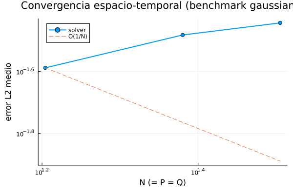

```julia
# Error L2 vs N en log-log, con pendiente de referencia O(1/N).
figN = plot(collect(Ns), errL2, xscale=:log10, yscale=:log10, marker=:circle, lw=2,
            label="solver", xlabel="N (= P = Q)", ylabel="error L2 medio",
            title="Convergencia espacio-temporal (benchmark gaussiano)")
plot!(figN, collect(Ns), errL2[1] .* (Ns[1] ./ collect(Ns)), ls=:dash, label="O(1/N)")
savefig(figN, "convergencia.png")
figN
```

## §5 — Costos generalizados $\Phi_\beta$

$\beta=1$ Wasserstein, $\beta=0$ mezcla lineal. El único cambio es el polinomio del paso proximal, ya en `prox_energia`. Barrido $\beta\in\{0,\tfrac12,1\}$.

**Código**

```julia
betas = (0.0, 0.5, 1.0)
Vbetas = Dict()
for β in betas
    @time Xb, Vb, hb = solve_bb(f0, f1, d; β=β, ε=ε, niter=600, verbose=200)
    Vbetas[β] = Vb
    spb, _ = dispersion(Vb[:,:,d[3]÷2,3])
    @printf("beta=%.2f  dispersion(t=0.5)=%.4f\n", β, spb)
end
```

```
    it=   1/600  ||div||=2.34e-03  minρ=9.07e-05
    it=  10/600  ||div||=2.31e-03  minρ=9.07e-05
    it=  20/600  ||div||=8.66e-04  minρ=9.07e-05
    it=  30/600  ||div||=4.69e-03  minρ=9.07e-05
    it=  40/600  ||div||=3.31e-03  minρ=9.07e-05
    it=  50/600  ||div||=6.49e-04  minρ=9.07e-05
    it=  60/600  ||div||=2.66e-03  minρ=9.07e-05
    it=  70/600  ||div||=3.20e-03  minρ=9.07e-05
    it=  80/600  ||div||=9.64e-04  minρ=9.07e-05
    it=  90/600  ||div||=1.39e-03  minρ=9.07e-05
    it= 100/600  ||div||=2.54e-03  minρ=9.07e-05
    it= 110/600  ||div||=1.29e-03  minρ=9.07e-05
    it= 120/600  ||div||=7.40e-04  minρ=9.07e-05
    it= 130/600  ||div||=1.68e-03  minρ=9.07e-05
    it= 140/600  ||div||=1.32e-03  minρ=9.07e-05
    it= 150/600  ||div||=5.20e-04  minρ=9.07e-05
    it= 160/600  ||div||=9.56e-04  minρ=9.07e-05
    it= 170/600  ||div||=1.10e-03  minρ=9.07e-05
    it= 180/600  ||div||=4.70e-04  minρ=9.07e-05
    it= 190/600  ||div||=4.87e-04  minρ=9.07e-05
    it= 200/600  ||div||=7.78e-04  minρ=9.07e-05
    it= 210/600  ||div||=4.44e-04  minρ=9.07e-05
    it= 220/600  ||div||=2.66e-04  minρ=9.07e-05
    it= 230/600  ||div||=4.67e-04  minρ=9.07e-05
    it= 240/600  ||div||=3.78e-04  minρ=9.07e-05
    it= 250/600  ||div||=2.55e-04  minρ=9.07e-05
    it= 260/600  ||div||=2.40e-04  minρ=9.07e-05
    it= 270/600  ||div||=2.79e-04  minρ=9.07e-05
    it= 280/600  ||div||=2.58e-04  minρ=9.07e-05
    it= 290/600  ||div||=2.16e-04  minρ=9.07e-05
    it= 300/600  ||div||=2.25e-04  minρ=9.07e-05
    it= 310/600  ||div||=2.42e-04  minρ=9.07e-05
    it= 320/600  ||div||=2.10e-04  minρ=9.07e-05
    it= 330/600  ||div||=1.96e-04  minρ=9.07e-05
    it= 340/600  ||div||=2.14e-04  minρ=9.07e-05
    it= 350/600  ||div||=1.98e-04  minρ=9.07e-05
    it= 360/600  ||div||=1.73e-04  minρ=9.07e-05
    it= 370/600  ||div||=1.79e-04  minρ=9.07e-05
    it= 380/600  ||div||=1.77e-04  minρ=9.07e-05
    it= 390/600  ||div||=1.57e-04  minρ=9.07e-05
```

[output cut: 134 more lines]

```
    it= 480/600  ||div||=1.38e-04  minρ=7.30e-05
    it= 490/600  ||div||=1.09e-04  minρ=7.69e-05
    it= 500/600  ||div||=1.17e-04  minρ=8.05e-05
    it= 510/600  ||div||=1.23e-04  minρ=8.26e-05
    it= 520/600  ||div||=1.44e-04  minρ=8.33e-05
    it= 530/600  ||div||=9.59e-05  minρ=8.34e-05
    it= 540/600  ||div||=1.01e-04  minρ=8.40e-05
    it= 550/600  ||div||=1.13e-04  minρ=8.41e-05
    it= 560/600  ||div||=7.40e-05  minρ=8.33e-05
    it= 570/600  ||div||=7.75e-05  minρ=8.32e-05
    it= 580/600  ||div||=1.05e-04  minρ=8.35e-05
    it= 590/600  ||div||=1.33e-04  minρ=8.40e-05
    it= 600/600  ||div||=1.65e-04  minρ=8.43e-05
 25.255962 seconds (920.29 k allocations: 47.295 GiB, 29.67% gc time)
beta=1.00  dispersion(t=0.5)=0.0580
```

**Código**

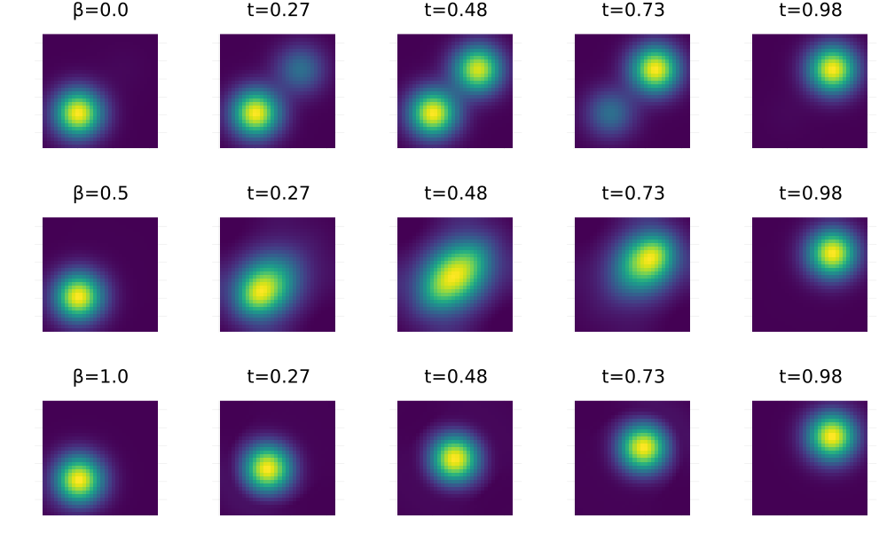

```julia
selb = round.(Int, range(1, d[3]; length=5))
cuadros = []
for β in betas, j in selb
    push!(cuadros, heatmap(Vbetas[β][:,:,j,3]', c=:viridis, axis=false, legend=false,
          colorbar=false, aspect_ratio=:equal,
          title=(j==selb[1] ? "β=$β" : "t=$(round((j-0.5)/d[3],digits=2))")))
end
figb = plot(cuadros..., layout=(length(betas), length(selb)), size=(1000,620))
savefig(figb, "barrido_beta.png")
figb
```

**Código**

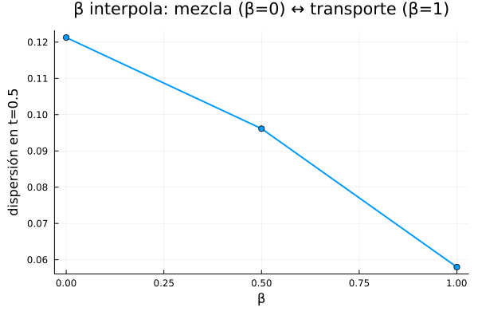

```julia
disps = [dispersion(Vbetas[β][:,:,d[3]÷2,3])[1] for β in betas]
figbd = plot(collect(betas), disps, marker=:circle, lw=2, legend=false,
             xlabel="β", ylabel="dispersión en t=0.5",
             title="β interpola: mezcla (β=0) ↔ transporte (β=1)")
savefig(figbd, "dispersion_vs_beta.png")
figbd
```

### §5.1 — Energía cinética: transporte vs. mezcla

La energía cinética física es $\int|m|^2/(2\rho)$ (el caso $\beta=1$). Evaluándola sobre cada solución del barrido —todas con la misma vara $\beta=1$— se mide cuánta energía gasta cada régimen: el transporte óptimo es el de menor energía, y la mezcla lineal la más cara.

**Código**

```
beta=0.00  J_cinetica=13.9665
beta=0.50  J_cinetica=4.9627
beta=1.00  J_cinetica=3.8272

Transporte (β=1) gasta 3.6x menos energía que la mezcla (β=0):  3.827  vs  13.966
```

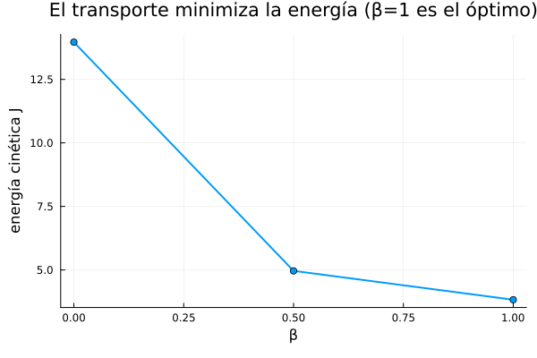

```julia
# Energia cinetica (evaluada con beta=1 SIEMPRE, la vara comun) de cada solucion del barrido.
Jbetas = [energia_BB(Vbetas[β]; ε=1e-4, β=1.0) for β in betas]
for (β, J) in zip(betas, Jbetas)
    @printf("beta=%.2f  J_cinetica=%.4f\n", β, J)
end
@printf("\nTransporte (β=1) gasta %.1fx menos energía que la mezcla (β=0):  %.3f  vs  %.3f\n",
        Jbetas[1]/Jbetas[end], Jbetas[end], Jbetas[1])
figJ = plot(collect(betas), Jbetas, lw=2, marker=:circle, legend=false,
            xlabel="β", ylabel="energía cinética J",
            title="El transporte minimiza la energía (β=1 es el óptimo)")
savefig(figJ, "energia_vs_beta.png")
figJ
```

**Código**

```julia
for epsv in (1e-3, 1e-4, 1e-5, 1e-6)
    Js = [energia_BB(Vbetas[β]; ε=epsv, β=1.0) for β in betas]
    @printf("eps=%.0e : ", epsv)
    for (β,J) in zip(betas,Js); @printf("β=%.2f→%.3f  ", β, J); end
    println()
end
```

```
eps=1e-03 : β=0.00→4.769  β=0.50→3.728  β=1.00→3.613
eps=1e-04 : β=0.00→13.966  β=0.50→4.963  β=1.00→3.827
eps=1e-05 : β=0.00→14.074  β=0.50→4.974  β=1.00→3.829
eps=1e-06 : β=0.00→14.074  β=0.50→4.974  β=1.00→3.829
```

**Código**

```julia
# Reevaluar la energía con eps fisico, sobre las Vbetas YA computadas (instantáneo)
Jbetas = [energia_BB(Vbetas[β]; ε=1e-5, β=1.0) for β in betas]
for (β, J) in zip(betas, Jbetas)
    @printf("beta=%.2f  J_cinetica=%.4f\n", β, J)
end
```

```
beta=0.00  J_cinetica=14.0743
beta=0.50  J_cinetica=4.9737
beta=1.00  J_cinetica=3.8288
```

### §5.2 — Imágenes de prueba sintéticas (utilidades)

Densidades de prueba a partir de formas: redimensión por promedio de área, `forma_disco`/`forma_cuadrado`, y `a_densidad` (masa 1, inversión opcional, piso de fondo por fracción, margen para el no-flujo). La carga de PNG reales (`cargar_gris`, requiere PNGFiles) vive en el notebook de morphing de fotos.

**Código**

```julia
# --- Redimensión por promedio de área (separable) ---
# Matriz de remuestreo 1D por solapamiento de intervalos: nin -> nout. Cada fila suma 1 (promedio).
function remuestreo_1d(nin, nout)
    W = zeros(nout, nin)
    for o in 1:nout
        a = (o-1)/nout; b = o/nout                # intervalo de salida [a,b]
        for i in 1:nin
            c = (i-1)/nin; d = i/nin              # intervalo de entrada [c,d]
            W[o,i] = max(0.0, min(b,d) - max(a,c)) # longitud de solapamiento
        end
        W[o,:] ./= sum(W[o,:])                     # normaliza a promedio
    end
    return W
end

# Redimensiona una matriz (H,Wd) -> (N,P) por promedio de área.
function redimensionar(A, dim2d)
    N, P = dim2d
    H, Wd = size(A)
    return remuestreo_1d(H, N) * A * remuestreo_1d(Wd, P)'
end

# --- Formas sintéticas de prueba (intensidad en [0,1], 1 = tinta) ---
function forma_disco(dim2d, centro, r)
    N, P = dim2d; cx, cy = centro
    x = range(0,1;length=N); y = range(0,1;length=P)
    return Float64[ (xi-cx)^2 + (yj-cy)^2 <= r^2 ? 1.0 : 0.0 for xi in x, yj in y]
end

function forma_cuadrado(dim2d, centro, lado)
    N, P = dim2d; cx, cy = centro
    x = range(0,1;length=N); y = range(0,1;length=P)
    return Float64[ (abs(xi-cx) <= lado/2 && abs(yj-cy) <= lado/2) ? 1.0 : 0.0 for xi in x, yj in y]
end

# --- Conversión intensidad -> densidad válida (masa 1, rho>0) ---
#   invertir    : true  => tinta oscura (valores bajos) pasa a masa alta (PNG típico, fondo blanco)
#                 false => los valores altos ya son masa (formas sintéticas con tinta=1)
#   frac_fondo  : fracción de la masa total asignada al fondo (controla contraste y rho>0)
#   margen      : nº de celdas de borde forzadas a fondo (deja la masa lejos de la frontera)
function a_densidad(raw, dim2d; invertir=true, frac_fondo=0.02, margen=1)
    N, P = dim2d
    f = redimensionar(Float64.(raw), dim2d)
    f .-= minimum(f); mx = maximum(f); mx > 0 && (f ./= mx)   # intensidad a [0,1]
    invertir && (f .= 1 .- f)                                 # tinta -> masa
    if margen > 0                                             # margen de fondo
        f[1:margen,:] .= 0; f[end-margen+1:end,:] .= 0
        f[:,1:margen] .= 0; f[:,end-margen+1:end] .= 0
    end
    s = sum(f)                                                # piso por fracción de masa de fondo:
    c = frac_fondo*s / (N*P*(1-frac_fondo))                   #   frac ≈ c*N*P/(s + c*N*P)
    f .+= c
    f ./= sum(f)                                              # masa 1
    return f
end
println("Datos (síntesis + conversión) listos.")
```

```
Datos (síntesis + conversión) listos.
```

**Código**

```
masa f0=1.000000000000  f1=1.000000000000   min f0=4.88e-06  f1=4.88e-06
```

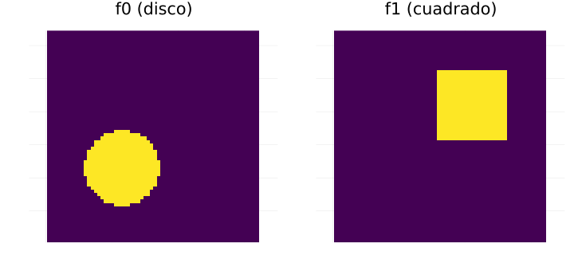

```julia
# TEST §6.1 (síntesis, sin solver): masa 1, positividad, y vista para confirmar orientación.
let
    N, P = 64, 64
    f0 = a_densidad(forma_disco((N,P),(0.35,0.35),0.18), (N,P); invertir=false, frac_fondo=0.02, margen=1)
    f1 = a_densidad(forma_cuadrado((N,P),(0.65,0.65),0.34), (N,P); invertir=false, frac_fondo=0.02, margen=1)
    @assert abs(sum(f0)-1) < 1e-12 && abs(sum(f1)-1) < 1e-12
    @assert minimum(f0) > 0 && minimum(f1) > 0
    @printf("masa f0=%.12f  f1=%.12f   min f0=%.2e  f1=%.2e\n", sum(f0), sum(f1), minimum(f0), minimum(f1))
    plot(heatmap(f0', c=:viridis, aspect_ratio=:equal, axis=false, colorbar=false, title="f0 (disco)"),
         heatmap(f1', c=:viridis, aspect_ratio=:equal, axis=false, colorbar=false, title="f1 (cuadrado)"),
         layout=(1,2), size=(720,340))
end
```

### §5.3 — Barrido de $\beta$ sobre imágenes de prueba (Objetivo 5.iii)

Las mismas formas resueltas con $\beta\in\{0,\tfrac12,1\}$: $\beta=0$ ($H^{-1}$) hace aparecer/desvanecer la masa, $\beta=1$ (Wasserstein) la transporta, $\beta=\tfrac12$ interpola. Se cuantifica con la dispersión en $t=0.5$ y la energía de transporte (vara común $\beta=1$).

**Código**

```julia
dβ  = (64, 64, 20)
f0β = a_densidad(forma_disco((dβ[1],dβ[2]),(0.35,0.35),0.18), (dβ[1],dβ[2]); invertir=false)
f1β = a_densidad(forma_cuadrado((dβ[1],dβ[2]),(0.65,0.65),0.34), (dβ[1],dβ[2]); invertir=false)
εβ  = min(minimum(f0β), minimum(f1β))

betas_img = (0.0, 0.5, 1.0)
Vβ = Dict()
for β in betas_img
    _, Vb, _ = solve_bb(f0β, f1β, dβ; β=β, ε=εβ, γ=1/230, niter=600, verbose=200)
    Vβ[β] = Vb
    sp, _ = dispersion(Vb[:,:,dβ[3]÷2,3])
    EB = energia_BB(Vb; ε=εβ, β=1.0)                      # energía de transporte (vara común β=1)
    @printf("β=%.2f  dispersión(t=0.5)=%.4f  energía_transporte=%.4f\n", β, sp, EB)
end
```

```
    it=   1/600  ||div||=8.21e-04  minρ=4.88e-06
    it=  10/600  ||div||=1.31e-03  minρ=4.88e-06
    it=  20/600  ||div||=5.50e-04  minρ=4.88e-06
    it=  30/600  ||div||=1.98e-03  minρ=4.88e-06
    it=  40/600  ||div||=1.75e-03  minρ=4.88e-06
    it=  50/600  ||div||=7.27e-04  minρ=4.88e-06
    it=  60/600  ||div||=1.26e-03  minρ=4.88e-06
    it=  70/600  ||div||=1.77e-03  minρ=4.88e-06
    it=  80/600  ||div||=8.35e-04  minρ=4.88e-06
    it=  90/600  ||div||=7.65e-04  minρ=4.88e-06
    it= 100/600  ||div||=1.28e-03  minρ=4.88e-06
    it= 110/600  ||div||=9.54e-04  minρ=4.88e-06
    it= 120/600  ||div||=6.68e-04  minρ=4.88e-06
    it= 130/600  ||div||=9.72e-04  minρ=4.88e-06
    it= 140/600  ||div||=8.96e-04  minρ=4.88e-06
    it= 150/600  ||div||=5.05e-04  minρ=4.88e-06
    it= 160/600  ||div||=6.27e-04  minρ=4.88e-06
    it= 170/600  ||div||=7.19e-04  minρ=4.88e-06
    it= 180/600  ||div||=6.36e-04  minρ=4.88e-06
    it= 190/600  ||div||=5.22e-04  minρ=4.88e-06
    it= 200/600  ||div||=5.96e-04  minρ=4.88e-06
    it= 210/600  ||div||=5.58e-04  minρ=4.88e-06
    it= 220/600  ||div||=4.33e-04  minρ=4.88e-06
    it= 230/600  ||div||=5.06e-04  minρ=4.88e-06
    it= 240/600  ||div||=5.05e-04  minρ=4.88e-06
    it= 250/600  ||div||=4.07e-04  minρ=4.88e-06
    it= 260/600  ||div||=3.87e-04  minρ=4.88e-06
    it= 270/600  ||div||=4.05e-04  minρ=4.88e-06
    it= 280/600  ||div||=3.41e-04  minρ=4.88e-06
    it= 290/600  ||div||=2.90e-04  minρ=4.88e-06
    it= 300/600  ||div||=3.21e-04  minρ=4.88e-06
    it= 310/600  ||div||=3.27e-04  minρ=4.88e-06
    it= 320/600  ||div||=2.78e-04  minρ=4.88e-06
    it= 330/600  ||div||=2.61e-04  minρ=4.88e-06
    it= 340/600  ||div||=2.46e-04  minρ=4.88e-06
    it= 350/600  ||div||=1.95e-04  minρ=4.88e-06
    it= 360/600  ||div||=1.65e-04  minρ=4.88e-06
    it= 370/600  ||div||=1.74e-04  minρ=4.88e-06
    it= 380/600  ||div||=1.42e-04  minρ=4.88e-06
    it= 390/600  ||div||=1.05e-04  minρ=4.88e-06
```

[output cut: 131 more lines]

```
    it= 470/600  ||div||=2.78e-04  minρ=-8.07e-06
    it= 480/600  ||div||=2.19e-04  minρ=-8.12e-06
    it= 490/600  ||div||=1.73e-04  minρ=-6.93e-06
    it= 500/600  ||div||=1.95e-04  minρ=-9.74e-06
    it= 510/600  ||div||=2.32e-04  minρ=-8.91e-06
    it= 520/600  ||div||=2.13e-04  minρ=-8.62e-06
    it= 530/600  ||div||=2.15e-04  minρ=-1.01e-05
    it= 540/600  ||div||=1.99e-04  minρ=-5.86e-06
    it= 550/600  ||div||=2.16e-04  minρ=-5.73e-06
    it= 560/600  ||div||=1.88e-04  minρ=-3.09e-06
    it= 570/600  ||div||=1.38e-04  minρ=-2.45e-06
    it= 580/600  ||div||=1.75e-04  minρ=-2.13e-06
    it= 590/600  ||div||=1.50e-04  minρ=-2.63e-06
    it= 600/600  ||div||=1.74e-04  minρ=-2.52e-06
β=1.00  dispersión(t=0.5)=0.0211  energía_transporte=1.7160
```

**Código**

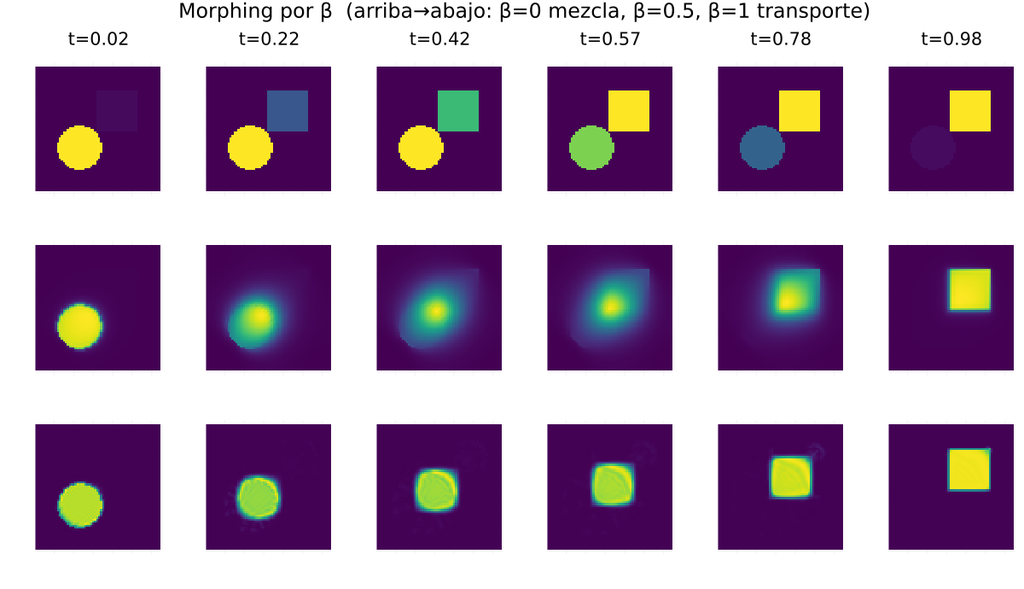

```julia
# Secuencias lado a lado: filas = β (0, 0.5, 1), columnas = t.
selβ = round.(Int, range(1, dβ[3]; length=6))
filas = Any[]
for β in betas_img
    for j in selβ
        titulo = β == betas_img[1] ? "t=$(round((j-0.5)/dβ[3],digits=2))" : ""
        push!(filas, heatmap(Vβ[β][:,:,j,3]', c=:viridis, axis=false, legend=false,
              colorbar=false, aspect_ratio=:equal, title=titulo))
    end
end
figβ = plot(filas..., layout=(length(betas_img), length(selβ)),
            size=(1200, 230*length(betas_img)),
            plot_title="Morphing por β  (arriba→abajo: β=0 mezcla, β=0.5, β=1 transporte)")
savefig(figβ, "morphing_betas.png")
figβ
```

### Referencias

Benamou & Brenier (2000); Papadakis, Peyré & Oudet (2014); Santambrogio (2015); Dolbeault, Nazaret & Savaré (2009).